# ggplot2: Elegant Graphics for Data Analysis

Peter Baumgartner

2017/02/17

Working on the exercises of chapter 2 of [ggplot2: Elegant Graphics for Data] Analysis(https://www.amazon.de/ggplot2-Elegant-Graphics-Data-Analysis/dp/331924275X/ref=sr_1_1?ie=UTF8&qid=1487435428&sr=8-1&keywords=ggplot2), second edition. See also the material on GitHub ggplot2-book, here especially [Chap.2](https://github.com/hadley/ggplot2-book/blob/master/ggplot.rmd).

> **Warning:** Keep in mind that I am still learning. There is no guarantee that my solutions are correct nor do they always present the most efficient way of doing things. Please feel free to comment on anything that you may think is wrong or somehow noteworthy (by writing an issue or by sending a pull request).

# 2 Exercises of Chapter 2

## 2.1 Exercises p.12/13

### 2.1.1 How to get more info about the `mpg` dataset?

List five functions that you could use to get more information about the `mpg` dataset.

- `class()` to see if it is a tibble and could be called without `head` or `tail` function
- `str()` to look at the structure
- `glimpse()` similiar but using the whole window width
- `head()` first 6 record of the data set
- `tail()` last 6 recors of the data set
- `View()` load file into RStudio data viewer
- `summary()` calculate summary statistics

```r
class(mpg)
```

```
[1] "tbl_df"     "tbl"        "data.frame"
```

```r
str(mpg)
```

```
Classes ‘tbl_df’, ‘tbl’ and 'data.frame':   234 obs. of  13 variables:
 $ manufacturer: chr  "audi" "audi" "audi" "audi" ...
 $ model       : chr  "a4" "a4" "a4" "a4" ...
 $ displ       : num  1.8 1.8 2 2 2.8 2.8 3.1 1.8 1.8 2 ...
 $ year        : int  1999 1999 2008 2008 1999 1999 2008 1999 1999 2008 ...
 $ cyl         : int  4 4 4 4 6 6 6 4 4 4 ...
 $ trans       : chr  "auto(l5)" "manual(m5)" "manual(m6)" "auto(av)" ...
 $ drv         : chr  "f" "f" "f" "f" ...
 $ cty         : int  18 21 20 21 16 18 18 18 16 20 ...
 $ hwy         : int  29 29 31 30 26 26 27 26 25 28 ...
 $ fl          : chr  "p" "p" "p" "p" ...
 $ class       : chr  "compact" "compact" "compact" "compact" ...
 $ cty_1       : num  13.1 11.2 11.8 11.2 14.7 13.1 13.1 13.1 14.7 11.8 ...
 $ hwy_1       : num  8.1 8.1 7.6 7.8 9 9 8.7 9 9.4 8.4 ...
```

```r
glimpse(mpg)
```

```
Observations: 234
Variables: 13
$ manufacturer <chr> "audi", "audi", "audi", "audi", "audi", "audi", "audi", "audi", "audi...
$ model        <chr> "a4", "a4", "a4", "a4", "a4", "a4", "a4", "a4 quattro", "a4 quattro",...
$ displ        <dbl> 1.8, 1.8, 2.0, 2.0, 2.8, 2.8, 3.1, 1.8, 1.8, 2.0, 2.0, 2.8, 2.8, 3.1,...
$ year         <int> 1999, 1999, 2008, 2008, 1999, 1999, 2008, 1999, 1999, 2008, 2008, 199...
$ cyl          <int> 4, 4, 4, 4, 6, 6, 6, 4, 4, 4, 4, 6, 6, 6, 6, 6, 6, 8, 8, 8, 8, 8, 8, ...
$ trans        <chr> "auto(l5)", "manual(m5)", "manual(m6)", "auto(av)", "auto(l5)", "manu...
$ drv          <chr> "f", "f", "f", "f", "f", "f", "f", "4", "4", "4", "4", "4", "4", "4",...
$ cty          <int> 18, 21, 20, 21, 16, 18, 18, 18, 16, 20, 19, 15, 17, 17, 15, 15, 17, 1...
$ hwy          <int> 29, 29, 31, 30, 26, 26, 27, 26, 25, 28, 27, 25, 25, 25, 25, 24, 25, 2...
$ fl           <chr> "p", "p", "p", "p", "p", "p", "p", "p", "p", "p", "p", "p", "p", "p",...
$ class        <chr> "compact", "compact", "compact", "compact", "compact", "compact", "co...
$ cty_1        <dbl> 13.1, 11.2, 11.8, 11.2, 14.7, 13.1, 13.1, 13.1, 14.7, 11.8, 12.4, 15....
$ hwy_1        <dbl> 8.1, 8.1, 7.6, 7.8, 9.0, 9.0, 8.7, 9.0, 9.4, 8.4, 8.7, 9.4, 9.4, 9.4,...
```

```r
head(mpg)
```

| manufacturer | model | displ | year | cyl | trans | drv | cty | hwy | fl | class | cty_1 | hwy_1 |
| --- | --- | --- | --- | --- | --- | --- | --- | --- | --- | --- | --- | --- |
| audi | a4 | 1.8 | 1999 | 4 | auto(l5) | f | 18 | 29 | p | compact | 13.1 | 8.1 |
| audi | a4 | 1.8 | 1999 | 4 | manual(m5) | f | 21 | 29 | p | compact | 11.2 | 8.1 |
| audi | a4 | 2.0 | 2008 | 4 | manual(m6) | f | 20 | 31 | p | compact | 11.8 | 7.6 |
| audi | a4 | 2.0 | 2008 | 4 | auto(av) | f | 21 | 30 | p | compact | 11.2 | 7.8 |
| audi | a4 | 2.8 | 1999 | 6 | auto(l5) | f | 16 | 26 | p | compact | 14.7 | 9.0 |
| audi | a4 | 2.8 | 1999 | 6 | manual(m5) | f | 18 | 26 | p | compact | 13.1 | 9.0 |

```r
tail(mpg)
```

| manufacturer | model | displ | year | cyl | trans | drv | cty | hwy | fl | class | cty_1 | hwy_1 |
| --- | --- | --- | --- | --- | --- | --- | --- | --- | --- | --- | --- | --- |
| volkswagen | passat | 1.8 | 1999 | 4 | auto(l5) | f | 18 | 29 | p | midsize | 13.1 | 8.1 |
| volkswagen | passat | 2.0 | 2008 | 4 | auto(s6) | f | 19 | 28 | p | midsize | 12.4 | 8.4 |
| volkswagen | passat | 2.0 | 2008 | 4 | manual(m6) | f | 21 | 29 | p | midsize | 11.2 | 8.1 |
| volkswagen | passat | 2.8 | 1999 | 6 | auto(l5) | f | 16 | 26 | p | midsize | 14.7 | 9.0 |
| volkswagen | passat | 2.8 | 1999 | 6 | manual(m5) | f | 18 | 26 | p | midsize | 13.1 | 9.0 |
| volkswagen | passat | 3.6 | 2008 | 6 | auto(s6) | f | 17 | 26 | p | midsize | 13.8 | 9.0 |

```r
names(mpg)
```

```
 [1] "manufacturer" "model"        "displ"        "year"         "cyl"          "trans"
 [7] "drv"          "cty"          "hwy"          "fl"           "class"        "cty_1"
[13] "hwy_1"
```

```r
summary(mpg)
```

```
 manufacturer          model               displ            year           cyl
 Length:234         Length:234         Min.   :1.600   Min.   :1999   Min.   :4.000
 Class :character   Class :character   1st Qu.:2.400   1st Qu.:1999   1st Qu.:4.000
 Mode  :character   Mode  :character   Median :3.300   Median :2004   Median :6.000
                                       Mean   :3.472   Mean   :2004   Mean   :5.889
                                       3rd Qu.:4.600   3rd Qu.:2008   3rd Qu.:8.000
                                       Max.   :7.000   Max.   :2008   Max.   :8.000
    trans               drv                 cty             hwy             fl
 Length:234         Length:234         Min.   : 9.00   Min.   :12.00   Length:234
 Class :character   Class :character   1st Qu.:14.00   1st Qu.:18.00   Class :character
 Mode  :character   Mode  :character   Median :17.00   Median :24.00   Mode  :character
                                       Mean   :16.86   Mean   :23.44
                                       3rd Qu.:19.00   3rd Qu.:27.00
                                       Max.   :35.00   Max.   :44.00
    class               cty_1           hwy_1
 Length:234         Min.   : 6.70   Min.   : 5.30
 Class :character   1st Qu.:12.40   1st Qu.: 8.70
 Mode  :character   Median :13.80   Median : 9.80
                    Mean   :14.85   Mean   :10.72
                    3rd Qu.:16.80   3rd Qu.:13.10
                    Max.   :26.10   Max.   :19.60
```

```r
View(mpg)
```

### 2.1.2 How can you find out what other datasets are included with ggplot2?

There is a listing on the special [documentation page](http://docs.ggplot2.org/current/index.html) for ggplot2 but there is also a general command `data()` for a listing of datasets for specific packages: More information with: `?data`

```r
data(package = "ggplot2")
?data
```

### 2.1.3 How to convert fuel consumption into fuel economy?

Apart from the US, most countries use *fuel consumption* (fuel consumed over fixed distance) rather than *fuel economy* (distance travelled with fixed amount of fuel). How could you convert cty and hwy into the European standard of l/100km?

For the calcuation see the page on [Metric Conversions](http://www.metric-conversions.org):

- 1 US liquid gallon = 3.78541 Litre
- 1 Mile = 1.609344 Kilometer

```r
mpgTol100km <- function(milespergallon){
  GalloLiter <- 3.785411784
  MileKilometer <- 1.609344
  l100km <- round((100*GalloLiter)/(milespergallon*MileKilometer), digits = 1)
  l100km
}
mpg <- mpg %>%
        mutate(cty_1 = mpgTol100km(cty),
                  hwy_1 = mpgTol100km(hwy))
```

### 2.1.4 How to get number of models and variations?

Which manufacturer has the most the models in this dataset? Which model has the most variations? Does your answer change if you remove the redundant specification of drive train (e.g. “pathfinder 4wd”, “a4 quattro”) from the model name?

```r
by_manufacturer <- group_by(mpg, manufacturer, sort = TRUE)
(models <- count(mpg, manufacturer, sort = TRUE))
```

| manufacturer | n |
| --- | --- |
| dodge | 37 |
| toyota | 34 |
| volkswagen | 27 |
| ford | 25 |
| chevrolet | 19 |
| audi | 18 |
| hyundai | 14 |
| subaru | 14 |
| nissan | 13 |
| honda | 9 |

[output cut: 5 more lines]

```r
by_models <- group_by(mpg, manufacturer, model)
per_model   <- summarise(by_models, nr = n())
(arrange(per_model, desc(nr)))
```

| manufacturer | model | nr |
| --- | --- | --- |
| dodge | caravan 2wd | 11 |
| dodge | ram 1500 pickup 4wd | 10 |
| dodge | dakota pickup 4wd | 9 |
| ford | mustang | 9 |
| honda | civic | 9 |
| volkswagen | jetta | 9 |
| audi | a4 quattro | 8 |
| jeep | grand cherokee 4wd | 8 |
| subaru | impreza awd | 8 |
| audi | a4 | 7 |

[output cut: 28 more lines]

```r
per_manufacturer <- summarise(per_model, "models" = n())
(arrange(per_manufacturer, desc(models)))
```

| manufacturer | models |
| --- | --- |
| toyota | 6 |
| chevrolet | 4 |
| dodge | 4 |
| ford | 4 |
| volkswagen | 4 |
| audi | 3 |
| nissan | 3 |
| hyundai | 2 |
| subaru | 2 |
| honda | 1 |

[output cut: 5 more lines]

Dodge has the model variants and Toyota the most models. Model Dodge Caravan 2wd has the most variation.

### 2.1.5 Changes if redundant specification of drive train is removed?

I do not understand the last part of the question: “Does your answer change if you remove the redundant specification of drive train (e.g.”pathfinder 4wd“,”a4 quattro“) from the model name?”

What exactly is redundant? I could remove “quattro” from model “a4” from “audi” but this does not make sense with “pathfinder 4wd” from “nissan”

## 2.2 Exercises p.14

### 2.2.1 Describe the relationship between cty and hwy

How would you describe the relationship between cty and hwy? Do you have any concerns about drawing conclusions from that plot?

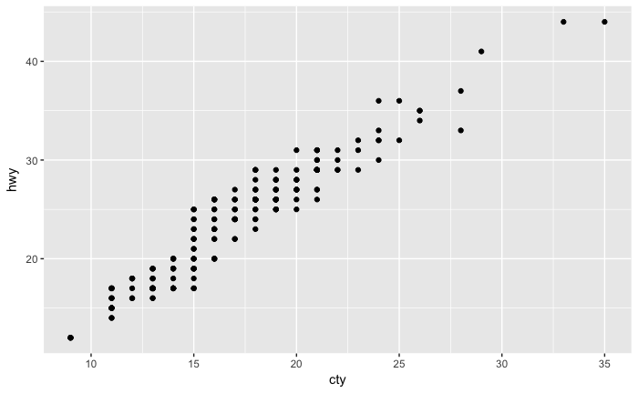

```r
ggplot(mpg, aes(cty, hwy)) +
        geom_point()
```

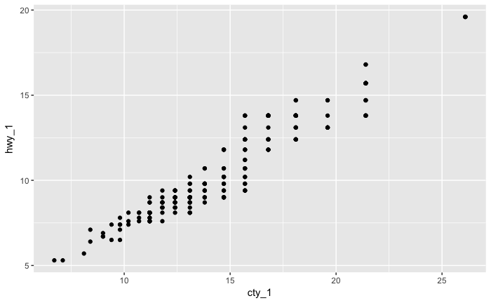

```r
ggplot(mpg, aes(cty_1, hwy_1)) +
        geom_point()
```

There is a positive linear regression: More fuel in the city corresponds to more fuel on the highway, even if the consumption on the highway is on a somewhat lower level.

There is a lot of overplotting in this graph.

### 2.2.2 What does the following plot show?

What does ggplot(mpg, aes(model, manufacturer)) + geom_point() show? Is it useful? How could you modify the data to make it more informative?

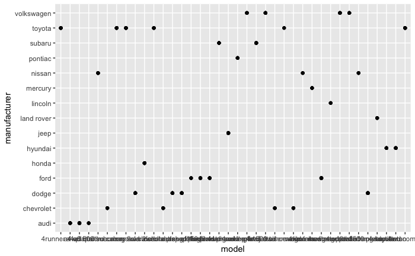

```r
ggplot(mpg, aes(model, manufacturer)) +
        geom_point()
```

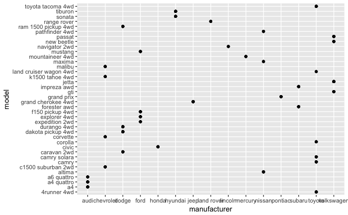

```r
ggplot(mpg, aes(manufacturer, model)) +
        geom_point()
```

The above graph shows the relationship between model and manufacturer. It is not useful as there is no relation between manufacturer and models. Every manufacturer is with its model separated and isolated, there is no connection or correlation. Moreover one cannot read the labels x axis and it would be ncessary to rotate the labels by 90 degrees.

[Manuel Steiner](https://github.com/M-E-Steiner/ggplot2-book-solutions/blob/master/Chapter2/Solutions_Chapter2.md#exercises-231-page-16) suggests to look at the total number of observations for each manufacturer-model combination using `geom_bar()`.

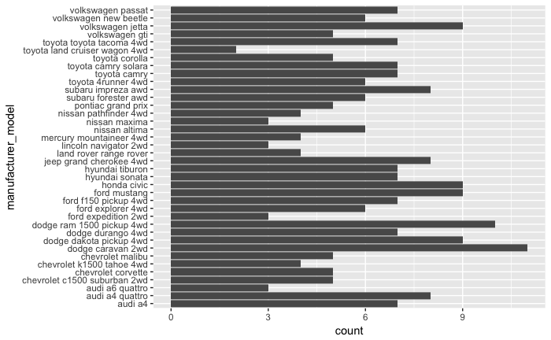

```r
df <- mpg %>%
  transmute(manufacturer_model = paste(manufacturer, model, sep = " "))
ggplot(df, aes(manufacturer_model)) +
  geom_bar() +
  coord_flip()
```

Maybe even better would be a graph with stacked bars, one bar for every manufacturer, divided by different colors representing the number of models of the manufacturer. But I do not know how to do this at the moment. (After I have learned more how to use `ggplot`, I will come back an try again.)

### 2.2.3 Describe the following plots

Describe the data, aesthetic mappings and layers used for each of the following plots. You’ll need to guess a little because you haven’t seen all the datasets and functions yet, but use your common sense! See if you can predict what the plot will look like before running the code.

- ggplot(mpg, aes(cty, hwy)) + geom_point()
- ggplot(diamonds, aes(carat, price)) + geom_point()
- ggplot(economics, aes(date, unemploy)) + geom_line()
- ggplot(mpg, aes(cty)) + geom_histogram()

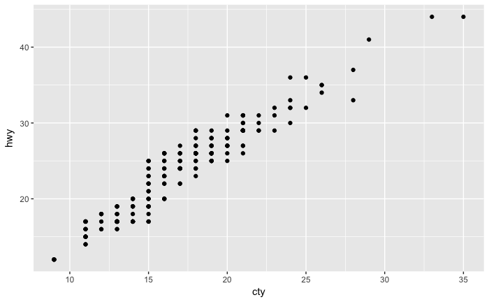

```r
ggplot(mpg, aes(cty, hwy)) + geom_point()
```

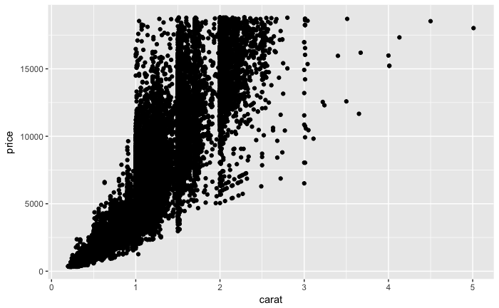

```r
ggplot(diamonds, aes(carat, price)) + geom_point()
```

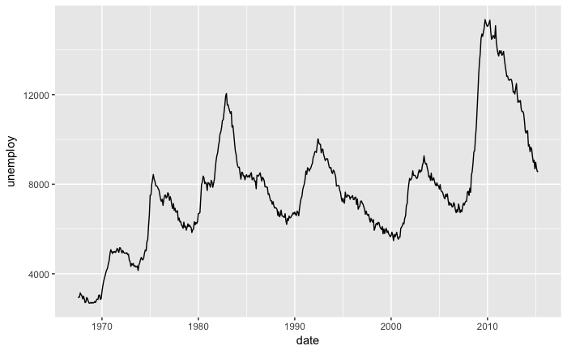

```r
ggplot(economics, aes(date, unemploy)) + geom_line()
```

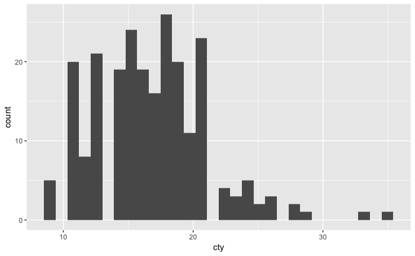

```r
ggplot(mpg, aes(cty)) + geom_histogram()
```

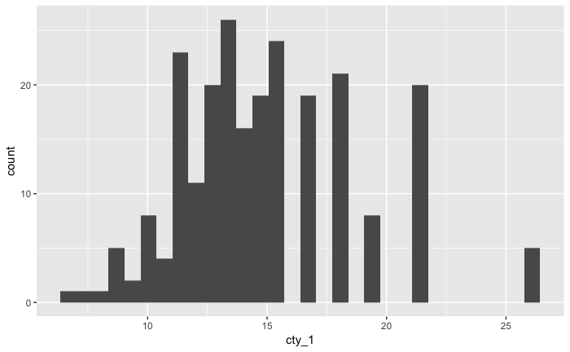

```r
ggplot(mpg, aes(cty_1)) + geom_histogram()
```

Again [Manuel Steiner](https://github.com/M-E-Steiner/ggplot2-book-solutions/blob/master/Chapter2/Solutions_Chapter2.md#exercises-231-page-16) claims that there is help with the following summary function:

```r
summary(ggplot(economics, aes(date, unemploy)) + geom_line())
```

```
data: date, pce, pop, psavert, uempmed, unemploy [574x6]
mapping:  x = date, y = unemploy
faceting: <ggproto object: Class FacetNull, Facet>
    compute_layout: function
    draw_back: function
    draw_front: function
    draw_labels: function
    draw_panels: function
    finish_data: function
    init_scales: function
    map: function
    map_data: function
    params: list
    render_back: function
    render_front: function
    render_panels: function
    setup_data: function
    setup_params: function
    shrink: TRUE
    train: function
    train_positions: function
    train_scales: function
    vars: function
    super:  <ggproto object: Class FacetNull, Facet>
-----------------------------------
geom_line: na.rm = FALSE
stat_identity: na.rm = FALSE
position_identity
```

It seems to me that this is no desription or explanation of the resulting graphs.

## 2.3 Exercises p.16

### 2.3.1 Exerpiment with color, shape and size aesthetics

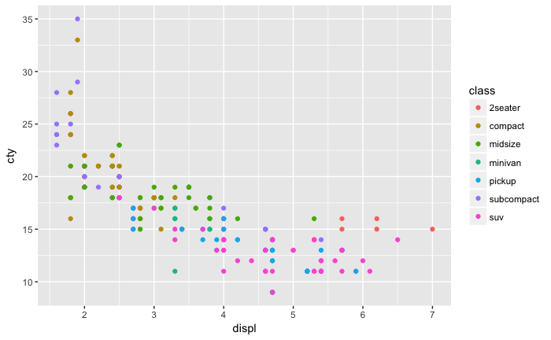

```r
vignette("ggplot2-specs")
ggplot(mpg, aes(displ, cty, color = class)) +
        geom_point()
```

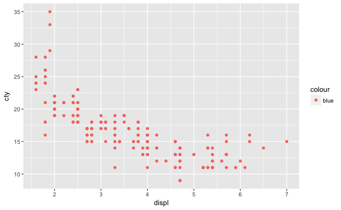

```r
ggplot(mpg, aes(displ, cty, color = "blue")) +
        geom_point()
```

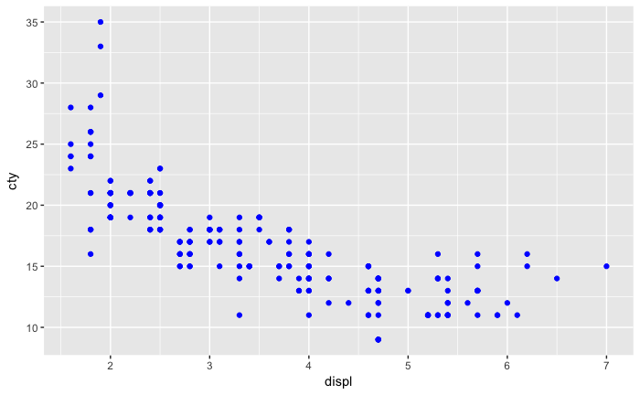

```r
ggplot(mpg, aes(displ, cty)) +
        geom_point(color = "blue")
```

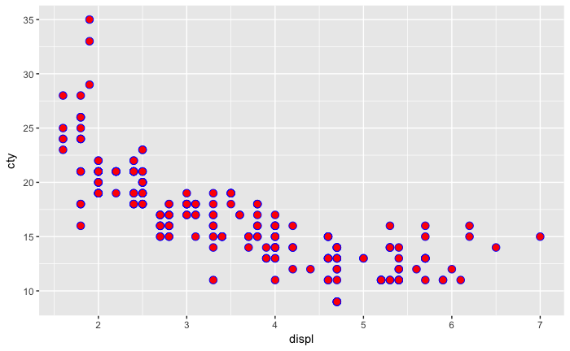

```r
ggplot(mpg, aes(displ, cty)) +
        geom_point(color = "blue", shape = 21, fill = "red", size = 3)
```

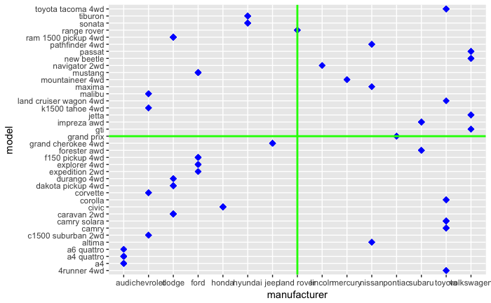

```r
ggplot(mpg, aes(manufacturer, model)) +
        geom_point(color = "blue", shape = 18, fill = "red", size = 3) +
        geom_abline(slope = -0.0, intercept = 20, colour = "green", size = 1) +
        geom_vline(xintercept = 8, colour = "green", size = 1)
```

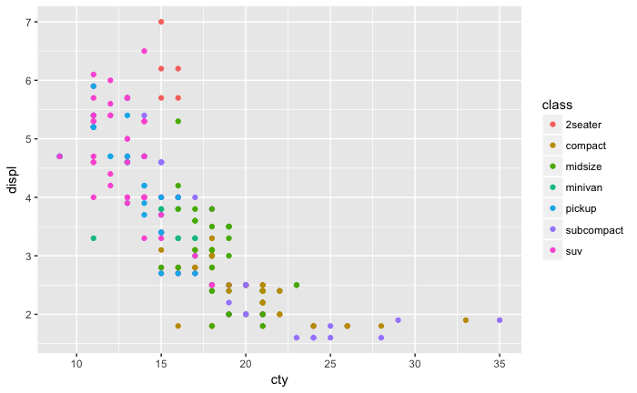

```r
# Categorial
ggplot(mpg, aes(cty, displ, colour = class)) +
  geom_point()
```

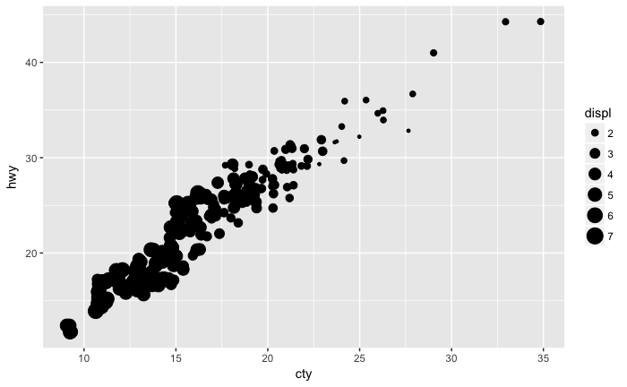

```r
# Continuous
ggplot(mpg, aes(cty, hwy, size = displ)) +
  geom_jitter()
```

```r
## Doesnt work for shape
# ggplot(mpg, aes(cty, hwy, shape = displ)) +
#   geom_jitter()
```

### 2.3.2 What happens if you map a continous variable to shape? Why?

```r
ggplot(mpg, aes(cty, hwy, shape = displ)) +
        geom_point()
```

```
Error: A continuous variable can not be mapped to shape
```

It throws an error, because a continuous variable can not be mapped to shape. All aesthetics that have a natural continuous scale can be used for both continuous and discrete variables. Shape doesn’t have a continuous scale so it throws an error.

### 2.3.3 What happens if you map trans to shape? Why?

> The shape palette can deal with a maximum of 6 discrete values because more than 6 becomes difficult to discriminate; you have 10. Consider specifying shapes manually if you must have them. Removed 96 rows containing missing values (geom_point).

When a discrete variable has more than 6 different values its hard to discriminate hence we get a warning.

### 2.3.4 How is drive train related to fuel economy?

The fuel economy of cars with front-wheel drive is generally better than of cars with 4 wd and rear wheel drive.

### 2.3.5 How is drive train related to engine size and class?

Cars with smaller engine size have front-wheel drive, pickup and suv have (with two exceptions in suv-clas) 4wd. 2seater and some of the subcompact cars have rear wheel drive.